# Encroachment Meta Model

Authors

Affiliation

Andrew Gray

The Norwegian Institute for Nature Research (NINA)

Ida M. Mienna

The Norwegian Institute for Nature Research (NINA)

Zander Venter

The Norwegian Institute for Nature Research (NINA)

Published

October 10, 2024

```
[1] "/data/P-Prosjekter2/412421_okologisk_tilstand_2024/Andrew/meta/github/ecRxiv_encroachment"
```

**Status**

This indicator documentation is incomplete and needs further developement before indicator values can be calculated.

**Recomended citation**

Gray, A. 2024 . Gjengroing v. 000.001 ecRxiv https://github.com/NINAnor/ecRxiv

**Version**

000.001

**Show metadata**

Table 1: Indicator metadata

| Indicator ID | NO_GJEN_002 |
| --- | --- |
| Indicator Name | Gjengroing |
| Country | Norway |
| Continent | Europe |
| Ecosystem Condition Typology Class | B3 - Functional State Characteristics |
| Realm | Terrestrial (T) |
| Biome | T3 Shrublands and shrubby woodlands biome |
| Ecosystem | T3.3 Cool temp heathlands |
| Year added | 2024 |
| Last update | 2024 |
| status | incomplete |
| Version | 000.001 |
| Version comment | NA |
| url | https://github.com/NINAnor/ecRxiv |

# Gjengroing

## 1. Introduction

The Norwegian word “gjengroing” is directly translated to “regrowing” in English. The gjengroing indicator describes the regrowth of woody vegetation (trees and bushes) in open ecosystems (wetland, semi- and naturally open areas) across Norway. We will use a spatial reference approach where reference areas define good or optimal vegetation regrowth heights. We have produced an index to assess regrowth using LiDAR-based canopy height data which is documented in our NO_GJEN indicator workbook. A primary limitation of this index, however, is its reliance on Norway’s national LiDAR survey, which is a static dataset with no planned resurvey (as of 2024). Here, we present a workflow to utilise airborne images to derive canopy height metrics using Meta’s [High Resolution Canopy Height](https://github.com/facebookresearch/HighResCanopyHeight/tree/main) backbone model. Airborne imagery is scheduled for national resurvey every 5 to 10 years and so this implementation of the gjengroing index may be used to monitor future changes in ecosystem condition. It is worth noting that the yet-to-be-launched P-Band radar satellite, Biomass, may provide an more precise method for future monitoring once data is available.

This workbook presents the necessary steps to download image tiles, run the model (in a Jupyter Notebook), validate the data against LiDAR canopy heights, compares LiDAR and modeled index scores and discusses the limitations of this approach.

## 2. About the underlying data

We rely on the following datasets:

- [Nature type polygons](https://kartkatalog.miljodirektoratet.no/Dataset/Details/2031) are used to identify reference areas with good ecological condition.
- Reference values for forest and good condition were taken from our LiDAR based index approach (NO_GJEN). Future implementations of this code will derive these values using Meta’s model.
- Moen’s [bioclimatic zones](https://artsdatabanken.no/Pages/181901/Bioklimatiske_soner). We use this to stratify reference (good condition) and forest (poor condition) heights by bioclimatic (also referred to as vegetation/climatic) zones.
- [FKB building footprints](https://kartkatalog.geonorge.no/metadata/fkb-bygning/8b4304ea-4fb0-479c-a24d-fa225e2c6e97) are used to isolate vegetation in the canopy height comparison.
- The [SSB 10km grid](https://kartkatalog.geonorge.no/metadata/statistisk-rutenett-5000m/32ac0653-d95c-446c-8558-bf9b79f4934e) is used for visualization purposes.
- The regional delineation for Norway (five regions) are used for aggregating and reporting gjengroing condition values.
- Norwegian Public Roads Administration, the Norwegian Institute for Bioeconomics (NIBIO) and the National Mapping Authority’s Norway in [Images aerial imagery](https://www.norgeibilder.no/).

### 2.1 Spatial and temporal resolution

This approach processes small image tiles over selected areas of interest and in its current form uses the most recently collected airborne image. Future itereations will include the ability to select date ranges for study. Temporal resolution presented here is circa 2019 to 2024.

### 2.2 Original units

The original units for ecological condition are meters. This is the height of the vegetation within reference, polygon and forest areas.

### 2.3 Additional comments about the dataset

None.

## 3. Indicator properties

### 3.1. ECT

### 3.2. Ecosystem condition characteristic

### 3.3. Other standards

Funksjonell sammensetning innen trofiske nivåer, reflecting the change in dominant growth form.

### 3.4. Collinearities with other indicators

There is possibly a collinearity with the [primary production indicator](https://rstudio.nina.no/p/b479cab0/#NDVI-indicator-natopen) (primærproduksjon). The primary production indicator uses the normalized difference vegetation index (NDVI) as a proxy for vegetation production. NDVI can be correlated with vegetation height and consequently yield similar results to the LiDAR-based gjengroing indicator.

## 4. Reference condition and values

### 4. 1. Reference condition

The methodology used to calculate the *gjengroing* indicator is outlined in the NO_GJEN indicator. NO_GJEN_002 is a proof of concept for using airborne imagery as an alternative to LiDAR data for producing canopy heigh maps and producing an ecosystem condition index. A full spatial analysis of the gjengroing condition is available in our original script.

#### 4.2.3. Spatial resolution and validity

## 5. Uncertainties

- The Meta model performs generally worse than LiDAR on very low lying vegetation (grasses ect) and tends to overestimate their height.
- In some instances, mismatch was due to temporal differences between LiDAR data and image capture, where trees had been removed or planted, natural growth had occurred or datasets were from different periods within the phenological cycle.
- The models poor performance over shaded areas has the potential to create large uncertainty when calculating median vegetation height over an area of interest. Shade would introduce significant error when comparing images from different years based on the time of year and time of day.
- The LiDAR based canopy height model was better able to resolve canopy structure and small gaps within vegetation canopy. This explains the majority of points where LiDAR canopy heights were very low but modeled canopy height was high.
- Georectification of the two datasets was sometimes resulting in mismatch at forest/vegetation edges
- The Meta model has visible edge effects on the output tiles. We have tried to minimise the influence of these by downloading tiles with overlapping regions, but these were also responsible for some mismatches.
- There may be different camera specifications for different airborne surveys which could affect inference. The normalisation steps within the model should mitigate these effects but we have not tested the impact of different sensor/lens combinations.

## 6. References

Tolan, J., Yang, H.-I., Nosarzewski, B., Couairon, G., Vo, H. V., Brandt, J., Spore, J., Majumdar, S., Haziza, D., Vamaraju, J., Moutakanni, T., Bojanowski, P., Johns, T., White, B., Tiecke, T., & Couprie, C. (2024). Very high resolution canopy height maps from RGB imagery using self-supervised vision transformer and convolutional decoder trained on aerial lidar. In Remote Sensing of Environment (Vol. 300, p. 113888). Elsevier BV. https://doi.org/10.1016/j.rse.2023.113888

## 7. Datasets

There are several datasets which are used in GEE which will not be imported into the R session here. These datasets have been obtained from the source and ingested into GEE by Zander Venter or Vegar Bakkestuen with the help of Miljødata section at NINA. They include

- [Nasjonalt grunnkart](https://nibio.brage.unit.no/nibio-xmlui/handle/11250/3120510)
- [LiDAR-derived digital elevation model from høydedata](https://hoydedata.no/LaserInnsyn/).
- [FKB building footprints](https://kartkatalog.geonorge.no/metadata/fkb-bygning/8b4304ea-4fb0-479c-a24d-fa225e2c6e97)
- [European forest clear-cut map](https://www.nature.com/articles/s41893-020-00609-y)
- Population polygons for naturlig åpen areas (GRUK).

The remaining datasets will be imported into the R session.

### 7.1 Downloading image tiles

#### 7.1.1 Setting directories

Here we define the directories to download images and image metadata (date) from and set the output folder for downloading tiles into.

```r
wms_base_url <- 'https://wms.geonorge.no/skwms1/wms.nib?SERVICE=WMS&VERSION=1.1.1&REQUEST=GetMap&SRS=EPSG:25833'
output_dir <- "data/tiles"
metadata_url <- 'https://tjenester.norgeibilder.no/rest/projectMetadata.ashx'
if (!dir.exists(output_dir)) {
  dir.create(output_dir, recursive = TRUE)
}
```

#### 7.1.2 Querying the airborne imagery metadata

This enables us to determine the date of the orthophoto tiles we will later download from the geonorge webserver.

```r
 query_metadata <- function(xmin, ymin, xmax, ymax, crs_code) {
  bbox_coords <- sprintf("%f,%f;%f,%f;%f,%f;%f,%f", xmin, ymin, xmin, ymax, xmax, ymax, xmax, ymin)

  param <- list(
    Filter = "ortofototype in (1,2,3,4,5,7,8,9,10,11,12)",
    Coordinates = bbox_coords,
    InputWKID = as.character(crs_code),
    ReturnMetadata = TRUE,
    StopOnCover = FALSE
  )

  response <- httr::GET(
    url = metadata_url,
    query = list(request = jsonlite::toJSON(param, auto_unbox = TRUE))
  )

  response_content <- httr::content(response, "text", encoding = "UTF-8")

  if (httr::http_status(response)$category != "Success") {
    return(NULL)
  }

  if (response_content == "" || is.null(response_content)) {
    return(NULL)
  }

  parsed_metadata <- tryCatch({
    fromJSON(response_content, flatten = TRUE)
  }, error = function(e) {
    return(NULL)
  })

  return(parsed_metadata)
}
```

The WMS provides the most recent image over each search area so we can pull the date from the metadata service to add to the tile filename.

```r
get_most_recent_metadata <- function(metadata) {
  filtered_metadata <- metadata$ProjectMetadata %>%
    filter(!is.na(properties.fotodato_date)) %>%
    mutate(fotodato_date = as.Date(properties.fotodato_date)) %>%
    arrange(desc(fotodato_date)) %>%
    slice(1)  # Get the most recent one

  if (nrow(filtered_metadata) == 0) {
    return(NULL)
  }

  return(filtered_metadata)
}
```

#### 7.1.3 Defining the area of interest

Here we include a shapefile of our area of intertest. The script will loop through all features in the shapefile, calculate their extent and query the WMS to download orthophotos within that extent in 256 x 256 pixel tiles. The AOI shape file should be in EPSG:25833. The shapefile provided here is a random sample of NiN polygons intended for testing this approach. Tile size must be kept to 256 to enable image normalisation as part of the preprocessing for running the meta model. Model performance has been tested at 1 m and 0.5 m resolution, with significantly better results at 0.5 m resolution. Imagery is available at finer scales which may again improve performance, but may also require additional tuning of the model’s hyperparameters for best results.

```r
AOIs <- sf::st_read("/data/P-Prosjekter2/412421_okologisk_tilstand_2024/Andrew/meta/github/ecRxiv_encroachment/indicators/NO_GJEN_002/data/AOIs.shp")
tile_size <- 256
resolution <- 0.5  # 0.5 meter resolution
```

#### 7.1.4 Downloading image tiles

This function downloads the orthophoto image tiles over our areas of interest.

```r
fn.getOrtoImages <- function(geometry, id_field, output_dir) {
  tryCatch({
    if (!st_is_valid(geometry)) {
      geometry <- st_make_valid(geometry)
    }

    geom_extent <- st_bbox(geometry)

    # Query metadata to get the most recent layer and date
    metadata <- query_metadata(geom_extent$xmin, geom_extent$ymin, geom_extent$xmax, geom_extent$ymax, 25833)

    if (is.null(metadata) || is.null(metadata$ProjectMetadata)) {
      return(NULL)
    }

    recent_project <- get_most_recent_metadata(metadata)

    if (is.null(recent_project)) {
      return(NULL)
    }

    recent_layer <- recent_project$properties.prosjektnavn
    image_date <- recent_project$properties.fotodato_date

    tile_width_meters <- tile_size * resolution
    tile_height_meters <- tile_size * resolution

    # Ensure tile size remains 256x256
    x_min <- floor(geom_extent$xmin / tile_width_meters) * tile_width_meters
    y_min <- floor(geom_extent$ymin / tile_height_meters) * tile_height_meters
    x_max <- ceiling(geom_extent$xmax / tile_width_meters) * tile_width_meters
    y_max <- ceiling(geom_extent$ymax / tile_height_meters) * tile_height_meters

    # Calculate number of tiles in x and y directions
    x_tiles <- ceiling((x_max - x_min) / tile_width_meters)
    y_tiles <- ceiling((y_max - y_min) / tile_height_meters)

    tile_index <- 1

    for (i in 0:(x_tiles - 1)) {
      for (j in 0:(y_tiles - 1)) {
        xmin <- x_min + i * tile_width_meters
        xmax <- xmin + tile_width_meters
        ymin <- y_min + j * tile_height_meters
        ymax <- ymin + tile_height_meters

        # Ensure the tiles have consistent size
        bbox_polygon <- st_polygon(list(matrix(c(
          xmin, ymin,
          xmin, ymax,
          xmax, ymax,
          xmax, ymin,
          xmin, ymin
        ), ncol = 2, byrow = TRUE)))
        bbox_polygon <- st_sfc(bbox_polygon, crs = st_crs(geometry))

        bbx <- st_bbox(bbox_polygon)

        # Construct WMS URL
        wms_url <- paste0(
          'https://wms.geonorge.no/skwms1/wms.nib?',
          'SERVICE=WMS&VERSION=1.1.1&REQUEST=GetMap',
          '&LAYERS=', URLencode(recent_layer),
          '&SRS=EPSG:25833',
          '&BBOX=', paste(bbx[c("xmin", "ymin", "xmax", "ymax")], collapse = ","),
          '&WIDTH=', tile_size,
          '&HEIGHT=', tile_size,
          '&FORMAT=image/tiff',
          '&TRANSPARENT=TRUE'
        )

        # Output file path using the "id" field, tile index, and image date in the file name
        t <- file.path(output_dir, paste0(image_date,"_", id_field, "_", tile_index, ".tif"))

        # GDAL translate options
        reso <- c('-tr', as.character(resolution), as.character(resolution), '-co', 'COMPRESS=NONE')

        # Try downloading the tile
        result <- try({
          sf::gdal_utils('translate', source = wms_url, destination = t, options = reso)
        }, silent = TRUE)

        # Retry mechanism
        for (k in 1:5) {
          if (!file.exists(t)) {
            Sys.sleep(1)
            result <- try({
              sf::gdal_utils('translate', source = wms_url, destination = t, options = reso)
            }, silent = TRUE)
          }
        }

        tile_index <- tile_index + 1
      }
    }

  }, error = function(e) {
    return(NULL)
  })
}
```

We can run the functions in parallel to speed up processing time adjust the number of cores to suit your setup.

```r
numCores <- 30

# Use mclapply for parallel processing
mclapply(1:nrow(AOIs), function(i) {
  geometry <- AOIs[i, ]
  id_field <- AOIs$id[i]  # Adjust field name if necessary
  fn.getOrtoImages(geometry, id_field, output_dir)
}, mc.cores = numCores)
```

### 7.3 Regions

To use our model output as an indicator, we need to bring in some datasets to stratify our inferred canopy height statistics. The regional delineation for Norway (five regions) are used for aggregating and reporting gjengroing condition values.

```r
regions <- sf::st_read("/data/P-Prosjekter2/412421_okologisk_tilstand_2024/Andrew/meta/github/ecRxiv_encroachment/indicators/NO_GJEN_002/data/regions.shp", options = "ENCODING=UTF8") %>%
  mutate(region = factor(region))
```

```
options:        ENCODING=UTF8
```

### 7.4 Bioclimatic regions

The [Moen’s bioclimatic regions](https://data.artsdatabanken.no//Natur_i_Norge/Natursystem/Beskrivelsessystem/Regional_naturvariasjon/Bioklimatisk_sone) are imported from NINA R/GeoSpatialData/ server.

```r
bioclim <- st_read('/data/R/GeoSpatialData/BiogeographicalRegions/Norway_VegetationZones_Moen/Original/Vector/soner.shp') %>%
  mutate(NAVN = ifelse(NAVN == 'S°rboreal', 'Sørboreal', NAVN))
bioclim <- st_transform(bioclim, st_crs(regions))
```

## 8. Spatial units

Image tiles must be 256 x 256 pixels to pass into the model for inference. We have tested the model using the compressed_SSLhuge_aerial.pth checkpoint on 1 m and 0.5 m pixel resolution and found 0.5 m to perform better.

## 9. Analyses

### 9.1 Modeling canopy height

Now that we have our tiles, we can pass them to the canopy height model. Please see [Meta’s High Resolution Canopy Height Model](https://github.com/facebookresearch/HighResCanopyHeight/tree/main) and Tolan et al. (2024) for more details on the model. Install the model according to the instructions on the facebookresearch github page.

To process the downloaded image tiles, please follow the gjengroingMetaModel.ipynb notebook included with this NO_GJEN_002 indicator. We have modified the inference scripts included in Meta’s model to work with our downloaded data.

### 9.2 Calculating the gjengroing index

#### 9.2.1 Importing the data

Here we import a shapefile of the areas of interest used to download image tiles. QGIS has been used to perform zonal statistics to calculate the median and maximum canopy height, calculated from both Meta model inference and LiDAR data, for each NiN feature.

```r
metaChm <- st_read("/data/P-Prosjekter2/412421_okologisk_tilstand_2024/Andrew/meta/github/ecRxiv_encroachment/indicators/NO_GJEN_002/data/NiN_metaTest.shp")
```

#### 9.2.1 Adding reference information

Here we add the region and bioclimate zone information to stratifiy the dataset

```r
library(dplyr)

# Calculate the intersection between polygons and climatic zones
main_climatic_overlap <- st_intersects(metaChm, bioclim)

# Extract the modal climatic zone for each polygon
metaChm$bioclim <- sapply(main_climatic_overlap, function(zones) {
  if (length(zones) > 0) {
    # Get the climatic zone IDs for overlapping polygons
    zone_ids <- bioclim$KLASSE[zones]

    # Find the most common climatic zone (modal value)
    zone_modal <- names(sort(table(zone_ids), decreasing = TRUE))[1]

    return(zone_modal)
  } else {
    return(NA)  # No overlap case
  }
})

# Calculate the intersection between polygons and regions
main_region_overlap <- st_intersects(metaChm, regions)

# Extract the modal (most common) region for each polygon
metaChm$regions <- sapply(main_region_overlap, function(regs) {
  if (length(regs) > 0) {
    # Get the region IDs for overlapping polygons
    region_ids <- regions$id[regs]

    # Find the most common region (modal value)
    region_modal <- names(sort(table(region_ids), decreasing = TRUE))[1]

    return(region_modal)
  } else {
    return(NA)  # No overlap case
  }
})

# Rename 'bioclim' to 'vegClimZone'
metaChm <- metaChm %>%
  rename(vegClimZone = bioclim)

# Add the region and vegClimZone labels
vegLookup <- tibble(
  vegClimZone = c(1, 2, 3, 4, 5),
  vegClimZoneLab = c('Boreonemoral sone (BN)', 'Lavalpin sone (LA)', 'Mellomboreal sone (MB)', 'Nordboreal sone (NB)', 'Sørboreal sone (SB)')
)

regionLookup <- tibble(
  regions = c(1, 2, 3, 4, 5),
  region_id = c('Nord-Norge', 'Midt-Norge', 'Østlandet', 'Vestlandet', 'Sørlandet')
)

# Ensure compatibility of column types for the join
metaChm <- metaChm %>%
  mutate(regions = as.numeric(regions),  # Convert 'regions' to numeric for the join
         vegClimZone = as.numeric(vegClimZone))  # Convert 'vegClimZone' to numeric for the join

# Add the region and vegClimZoneLab columns to metaChm
metaChm <- metaChm %>%
  left_join(regionLookup, by = 'regions') %>%
  left_join(vegLookup, by = 'vegClimZone')

# View the updated metaChm
head(metaChm)
```

```
Simple feature collection with 6 features and 16 fields
Geometry type: POLYGON
Dimension:     XY
Bounding box:  xmin: -15716.52 ymin: 6578537 xmax: 841415.5 ymax: 7822781
Projected CRS: ETRS89 / UTM zone 33N
     DSM_max DSM_median  meta_max geo_type tilstnd              id     slope
1 5.01190186 5.01190186 7.0439968  Polygon    <NA> NINFP1810035734 35.838253
2 1.10329056 0.16404343 1.8785635  Polygon  darlig NINFP2110065346  2.754065
3 7.89710999 0.58419800 7.7905231  Polygon  darlig NINFP2010012190 10.828519
4 4.75721359 0.14787704 4.2851658  Polygon  darlig NINFP2010053867  4.717192
5 0.37719727 0.03491211 3.1292784  Polygon  darlig NINFP2210096762  3.352139
6 0.07987976 0.04281875 0.4133247  Polygon     god NINFP2110032175  3.292785
        dem meta_media        hvdksys year month vegClimZone regions  region_id
1 306.17502  2.3452251 Naturlig aapne 2020     8           2       4 Vestlandet
2  49.30714  0.4110546 Naturlig aapne 2019     6           5       1 Nord-Norge
3 135.28822  0.7026022 Naturlig aapne 2023     8           2       3  Østlandet
4  21.10746  0.4111846 Naturlig aapne 2019     7           4       1 Nord-Norge
5 822.47943  1.1716730 Naturlig aapne 2020     8           5       3  Østlandet
6 226.09915  0.4101001 Naturlig aapne 2018     7           5       1 Nord-Norge
        vegClimZoneLab                       geometry
1   Lavalpin sone (LA) POLYGON ((-15716.52 6578541...
2  Sørboreal sone (SB) POLYGON ((712661.2 7697595,...
3   Lavalpin sone (LA) POLYGON ((244670.1 6695162,...
4 Nordboreal sone (NB) POLYGON ((439298.1 7353164,...
5  Sørboreal sone (SB) POLYGON ((139051.8 6714433,...
6  Sørboreal sone (SB) POLYGON ((841400.6 7822738,...
```

Import forest heights per region-bioclimatic zone strata.

```r
cleanRegClim <- function(data){

  dataOut <- data %>%
    mutate(region=ifelse(region_id == 1, 'Nord-Norge',
                         ifelse(region_id == 2, 'Midt-Norge',
                                ifelse(region_id == 3, 'Østlandet',
                                       ifelse(region_id == 4, 'Vestlandet', 'Sørlandet'))))) %>%

    mutate(vegClimZone = round(vegClimZone)) %>%
    left_join(vegLookup, by = 'vegClimZone') %>%
    dplyr::select(-region_id, -vegClimZone) %>%
    drop_na(vegClimZoneLab, region)

  return (dataOut)

}


skog_region_bioclim <- read_csv("/data/P-Prosjekter2/412421_okologisk_tilstand_2024/Ida/From_GEE/vegHeights_skog_climZoneRegion.csv")
names(skog_region_bioclim)[2:4] <- c("vegClimZone","skog","region_id")
```

Add the forest height metric to each NiN polygon based on bioclimatic and region zones.

```r
skog_region_bioclim <- as_tibble(skog_region_bioclim)

# Select the necessary columns from skog_region_bioclim before the join
#skog_region_bioclim_selected <- skog_region_bioclim %>%
 # dplyr::select(climZone, region, p90_height)

# Add "skog" column to metaChm by joining with skog_region_bioclim
metaChm <- metaChm %>%
  left_join(
    skog_region_bioclim,
    by = c("vegClimZone", "regions" = "region_id")
  )

# View the updated metaChm
head(metaChm)
```

```
Simple feature collection with 6 features and 19 fields
Geometry type: POLYGON
Dimension:     XY
Bounding box:  xmin: -15716.52 ymin: 6578537 xmax: 841415.5 ymax: 7822781
Projected CRS: ETRS89 / UTM zone 33N
     DSM_max DSM_median  meta_max geo_type tilstnd              id     slope
1 5.01190186 5.01190186 7.0439968  Polygon    <NA> NINFP1810035734 35.838253
2 1.10329056 0.16404343 1.8785635  Polygon  darlig NINFP2110065346  2.754065
3 7.89710999 0.58419800 7.7905231  Polygon  darlig NINFP2010012190 10.828519
4 4.75721359 0.14787704 4.2851658  Polygon  darlig NINFP2010053867  4.717192
5 0.37719727 0.03491211 3.1292784  Polygon  darlig NINFP2210096762  3.352139
6 0.07987976 0.04281875 0.4133247  Polygon     god NINFP2110032175  3.292785
        dem meta_media        hvdksys year month vegClimZone regions  region_id
1 306.17502  2.3452251 Naturlig aapne 2020     8           2       4 Vestlandet
2  49.30714  0.4110546 Naturlig aapne 2019     6           5       1 Nord-Norge
```

[output cut: 18 more lines]

Import the reference height data to be used as “good” condition reference values

```r
refvaatmark  <- read.csv('/data/P-Prosjekter2/412421_okologisk_tilstand_2024/Andrew/meta/github/ecRxiv_encroachment/indicators/NO_GJEN_002/data/refvaatmark.csv', sep = ",")
refaapne  <- read.csv('/data/P-Prosjekter2/412421_okologisk_tilstand_2024/Andrew/meta/github/ecRxiv_encroachment/indicators/NO_GJEN_002/data/refaapne.csv', sep = ";")
refsemi  <- read.csv('/data/P-Prosjekter2/412421_okologisk_tilstand_2024/Andrew/meta/github/ecRxiv_encroachment/indicators/NO_GJEN_002/data/refsemi.csv', sep = ",")
```

Split our cnopy height dataframe into ecosystem types

```r
metaAapne <- metaChm %>%
  filter(hvdksys == "Naturlig aapne")

# 2. Extract "Semi-naturlig"
metaNaturlig <- metaChm %>%
  filter(hvdksys == "Semi-naturlig")

# 3. Extract "Vaatmark"
metaVaatmark <- metaChm %>%
  filter(hvdksys == "Vaatmark")
```

Add the “good” reference values to the separate ecosystem types

```r
metaAapne <- metaAapne %>%
  left_join(
    refaapne,
    by = c("vegClimZoneLab", "region_id" = "region")
  )

metaVaatmark <- metaVaatmark %>%
  left_join(
    refvaatmark,
    by = c("vegClimZoneLab", "region_id" = "region")
  )

metaNaturlig <- metaNaturlig %>%
  left_join(
    refsemi,
    by = c("vegClimZoneLab", "region_id" = "region")
  )
```

Filter out NA values and join back together in a dataframe

```r
metaNaturlig <- metaNaturlig %>%
  filter(!is.na(ref) & !is.na(skog))
metaAapne <- metaAapne %>%
  filter(!is.na(ref) & !is.na(skog))
metaVaatmark <- metaVaatmark %>%
  filter(!is.na(ref) & !is.na(skog))

metaCHM <- bind_rows(metaAapne, metaNaturlig, metaVaatmark)
```

#### 9.2.2 Calculating the index

We will calculate the gjengroing index for each population polygon using a Sigmoid scaling function.

```r
# Define Sigmoid scaling function
scaleSigmoid <- function(pop, ref, skog) {
  # Scale the population height between the reference (good condition) and forest height (poor condition)
  indicator_LowHigh <- (pop - ref) / (skog - ref)
  indicator_LowHigh[indicator_LowHigh < 0] <- 0
  indicator_LowHigh[indicator_LowHigh > 1] <- 1
  indicator_sigmoid <- 100.68 * (1 - exp(-5 * (indicator_LowHigh)^2.5)) / 100
  return(round(indicator_sigmoid, 4))
}
```

Now calculate the index using the median canopy height value from the meta model output

```r
metaCHM <- metaCHM %>%
  # Apply the scaling function to calculate the index for each polygon
  mutate(
    indexMeta = scaleSigmoid(meta_media, ref, skog),
    # Invert the index because shorter vegetation is considered better condition
    indexMeta = 1 - indexMeta
  )

# View the updated metaChm
head(metaCHM)
```

```
Simple feature collection with 6 features and 21 fields
Geometry type: POLYGON
Dimension:     XY
Bounding box:  xmin: 139051.8 ymin: 6695119 xmax: 841415.5 ymax: 7822781
Projected CRS: ETRS89 / UTM zone 33N
     DSM_max DSM_median  meta_max geo_type tilstnd              id     slope
1 1.10329056 0.16404343 1.8785635  Polygon  darlig NINFP2110065346  2.754065
2 7.89710999 0.58419800 7.7905231  Polygon  darlig NINFP2010012190 10.828519
3 4.75721359 0.14787704 4.2851658  Polygon  darlig NINFP2010053867  4.717192
4 0.37719727 0.03491211 3.1292784  Polygon  darlig NINFP2210096762  3.352139
5 0.07987976 0.04281875 0.4133247  Polygon     god NINFP2110032175  3.292785
6 1.04078722 0.02731074 2.8481126  Polygon     god NINFP1910019420  2.220176
         dem meta_media        hvdksys year month vegClimZone regions
1  49.307144  0.4110546 Naturlig aapne 2019     6           5       1
2 135.288223  0.7026022 Naturlig aapne 2023     8           2       3
```

[output cut: 25 more lines]

And now calculate it from the LiDAR based canopy height model

```r
metaCHM <- metaCHM %>%
  # Apply the scaling function to calculate the index for each polygon
  mutate(
    indexLiD = scaleSigmoid(DSM_median, ref, skog),
    # Invert the index because shorter vegetation is considered better condition
    indexLiD = 1 - indexLiD
  )

# View the updated metaChm
head(metaCHM)
```

```
Simple feature collection with 6 features and 22 fields
Geometry type: POLYGON
Dimension:     XY
Bounding box:  xmin: 139051.8 ymin: 6695119 xmax: 841415.5 ymax: 7822781
Projected CRS: ETRS89 / UTM zone 33N
     DSM_max DSM_median  meta_max geo_type tilstnd              id     slope
1 1.10329056 0.16404343 1.8785635  Polygon  darlig NINFP2110065346  2.754065
2 7.89710999 0.58419800 7.7905231  Polygon  darlig NINFP2010012190 10.828519
3 4.75721359 0.14787704 4.2851658  Polygon  darlig NINFP2010053867  4.717192
4 0.37719727 0.03491211 3.1292784  Polygon  darlig NINFP2210096762  3.352139
5 0.07987976 0.04281875 0.4133247  Polygon     god NINFP2110032175  3.292785
6 1.04078722 0.02731074 2.8481126  Polygon     god NINFP1910019420  2.220176
         dem meta_media        hvdksys year month vegClimZone regions
1  49.307144  0.4110546 Naturlig aapne 2019     6           5       1
2 135.288223  0.7026022 Naturlig aapne 2023     8           2       3
```

[output cut: 25 more lines]

## 10. Results

### 10.1 Validation of canopy height inference

After running inference on the meta model, we have raster tiles of canopy height estimate corresponding to our downloaded image tiles. These were mosaiced into a virtual raster for validation. Sampling for validation was performed in QGIS and consisted of creating 1000 random points within each NiN polygon used as AOI’s for the tile download. These were used to sample the modeled canopy height as well as the canopy height based on LiDAR data.

Initial validation attempts showed poor performance relating to airborne images taken outside of the months of June, July and August. This was expected, since the model was trained on vegetation at peak foliation. For this reason, imagery collected outside of this month range was excluded from validation. We also filtered out points that intersected with the FKB building footprints layer, points that were in shadow (calculated by sampling the blue channel of the input RGB images and filtering out based on a threshold value). The resulting csv file after filtering contains c. 30000 points with LiDAR and Meta model based canopy heights. Future iterations of this script will automate these vaildation steps.

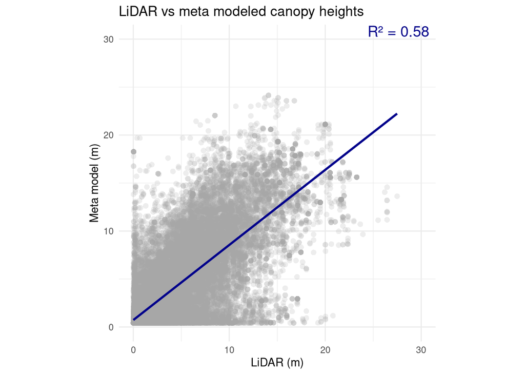

```r
val <- read.csv('/data/P-Prosjekter2/412421_okologisk_tilstand_2024/Andrew/meta/github/ecRxiv_encroachment/indicators/NO_GJEN_002/data/NiNpointSamples.csv')
ggplot(val, aes(x = lidmax, y = metamax)) +
  geom_point(size=2.5, alpha=0.2, stroke=0, color = 'darkgray') +  # Scatter plot
  geom_smooth(method = "lm", se = FALSE, color = "darkblue") +  # Line of best fit
  theme_minimal() +  # Clean theme
  coord_fixed(ratio = 1) +  # Square aspect ratio
  labs(title = "LiDAR vs meta modeled canopy heights", x = "LiDAR (m)", y = "Meta model (m)") +  # Labels
  # Add R-squared value to the plot
  annotate("text", x = Inf, y = Inf, label = paste("R² =", round(summary(lm(metamax ~ lidmax, data = val))$r.squared, 2)),
           hjust = 1.1, vjust = 1.1, size = 5, color = "darkblue")+ xlim(0,30) + ylim(0,30)
```

### 10.2 Comparison of modelled vs LiDAR gjengroing index

We can plot a scatterplot to compare LiDAR based index with the Meta based index.

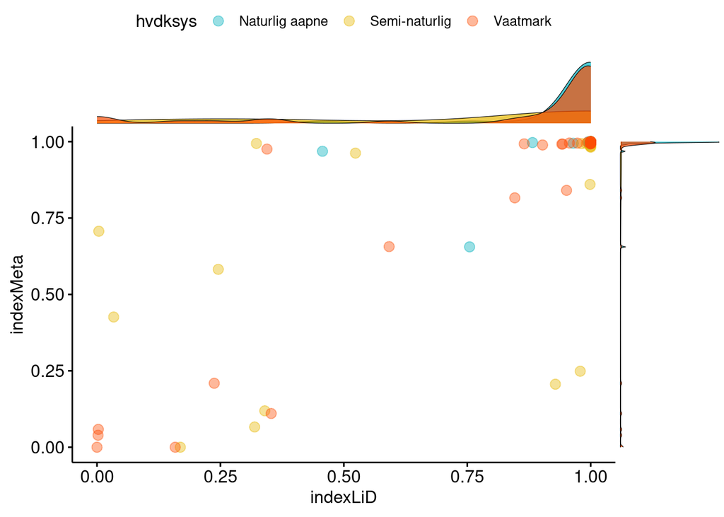

```r
ggscatterhist(
  metaCHM, x = "indexLiD", y = "indexMeta",
  color = "hvdksys", size = 3, alpha = 0.4,
  palette = c("#00AFBB", "#E7B800", "#FC4E07"),
  margin.params = list(fill = "hvdksys", color = "black", size = 0.2)
  )
```

We can also compare this data with a box plot:

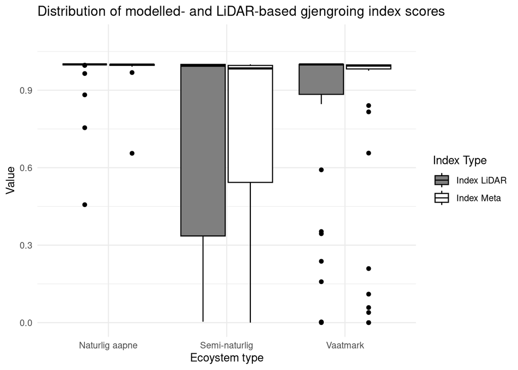

```r
chm_long <- metaCHM %>%
  dplyr::select(hvdksys, indexMeta, indexLiD) %>%
  pivot_longer(cols = c(indexMeta, indexLiD),
               names_to = "index_type",
               values_to = "value")

# Create the bar plot with dodged bars
ggplot(chm_long, aes(x = hvdksys, y = value, fill = index_type)) +
  geom_boxplot(position = position_dodge(width = 0.8), color = "black") +
  scale_fill_manual(values = c("indexLiD" = "grey50", "indexMeta" = "white"),
                    labels = c("indexLiD" = "Index LiDAR", "indexMeta" = "Index Meta")) +
  labs(
    title = "Distribution of modelled- and LiDAR-based gjengroing index scores",
    x = "Ecoystem type",
    y = "Value",
    fill = "Index Type"
  ) +
  theme_minimal() +
   ylim(0, 1.1)
```

[interactive chart not shown]